# Visualizing Wahl-O-Mat & zero-shot classification

Author

Nico Blokker

Published

February 14, 2023

The [Wahl-O-Mat](https://www.bpb.de/themen/wahl-o-mat/) probably is Germany’s most popular voting-advice-application. Users can compare their preferences on certain policies to those of political parties. Party-Policy relations are often visualized as bipartite network or as either of its projections.

The Wahl-O-Mat also contains justifications, in which parties argue why they support or oppose the policy in question. However, as opposed to the policies, justifications are not labeled. In this post, I first automatically label the justifications following the Codebook from the *Media Frames Corpus* (Card et al. 2015), only to subsequently visualize the Party-Policy-Justification network (shown below, see Blokker et al. 2022).[^1]

### Label justifications from WoM

I use Sentence-BERT (Reimers and Gurevych 2019) to automatically assign one of the categories contained in the Codebook: Each justification is compared against the category and its description (Card et al. 2015: 439). The most similar category is assigned as label (`label_auto`) and subsequently used as node in the network. Policies are indicated by the starting “T_” (for thesis) and black font, whereas justifications are in grey and start with “F_” (for frame). The color of the edges signals the corresponding party.

Examples Wahl-O-Mat 2021 in Germany

| party | thesis | position | justification | label_auto |
| --- | --- | --- | --- | --- |
| cdu | Abschaffung des Familiennachzugs | stimme nicht zu | Wir wollen, dass die Zahl der Flüchtlinge, die zu uns kommen, dauerhaft niedrig bleibt. Grundsätzlich gilt, dass anerkannte Flüchtlinge einen Anspruch auf den Nachzug ihrer Kernfamilie haben. Eine Aus… | Cultural identity |
| spd | Abschaffung des Familiennachzugs | stimme nicht zu | Wer vor Verfolgung, Tod und Terror zu uns geflohen ist und als schutzberechtigt anerkannt ist, soll auch seine Familie in Sicherheit bringen dürfen. Das gebietet die Menschlichkeit und das internation… | Security and defense |
| afd | Abschaffung des Familiennachzugs | stimme zu | Familiennachzug für Flüchtlinge erhöht die unqualifizierte Zuwanderung nach Deutschland um ein Vielfaches und endet fast immer dauerhaft im sozialen Netz. Wir lehnen dies ab. Die Familieneinheit kann … | Cultural identity |

### Visualize tripartite Network

In the following example network, one can for example see that the Left party (purple) opposes – indicated by the dashed line – to abolish family reunifications (for migrants) because of reasons of ‘fairness and equality’. The AfD on the other hand supports this policy for reasons of ‘Cultural Identity’.

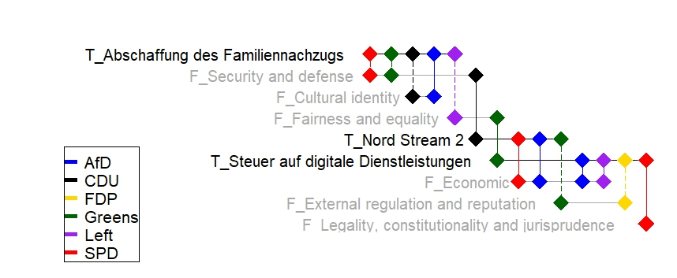

Tripartite Network representation

### Conclusion

In this post zero-shot classification is used to quickly categorize unlabeled texts. These labels are in turn used as additional building blocks of tripartite network structures. The resulting network gives a concise overview of a) the positions parties take with regard to b) certain policies and c) with what reasoning.

## References

Blokker, Nico, Tanise Ceron, André Blessing, Erenay Dayanik, Sebastian Haunss, Jonas Kuhn, Gabriella Lapesa, and Sebastian Padó. 2022. “Why Justifications of Claims Matter for Understanding Party Positions.” In *Proceedings of the 2nd Workshop on Computational Linguistics for Political Text Analysis*. https://old.gscl.org/media/pages/arbeitskreise/cpss/cpss-2022/workshop-proceedings-2022/254133848-1662996909/cpss-2022-proceedings.pdf.

Card, Dallas, Amber Boydstun, Justin H Gross, Philip Resnik, and Noah A Smith. 2015. “The Media Frames Corpus: Annotations of Frames Across Issues.” In *Proceedings of the 53rd Annual Meeting of the Association for Computational Linguistics and the 7th International Joint Conference on Natural Language Processing (Volume 2: Short Papers)*, 438–44.

Longabaugh, William JR. 2012. “Combing the Hairball with BioFabric: A New Approach for Visualization of Large Networks.” *BMC Bioinformatics* 13 (1): 275. https://doi.org/10.1186/1471-2105-13-275.

Pedersen, Thomas Lin. 2022. *Ggraph: An Implementation of Grammar of Graphics for Graphs and Networks*. https://CRAN.R-project.org/package=ggraph.

Reimers, Nils, and Iryna Gurevych. 2019. “Sentence-BERT: Sentence Embeddings Using Siamese BERT-Networks.” arXiv. https://doi.org/10.48550/arXiv.1908.10084.

## Footnotes

[^1]: To learn more about the “biofabric” layout refer to Longabaugh (2012) and the `GGraph`- Package (Pedersen 2022).